# Analysis of COVID-19 Serial Interval

## 4.2 Data visualization

### 4.2.1 Distribution of the serial intervals

The figures that follow are the estimated serial interval time for COVID-19 transmission events between January 21 - February 28, 2020 in mainland China.

```r
# convert column names into lower case
names(covid19) <- tolower(names(covid19))

# replace non-alphabet characters to underscores
x <-gsub("[^A-Za-z]", "_", names(covid19))
# replace trailing underscores to just one underscore
x <- gsub("_{2,}", "_", x)

# change some of the spelling
x[11:13] <- c('secondary_symptom_onset_date', 'secondary_age', 'secondary_sex')

# apply changes to column names/variables
names(covid19) <- x
```

```r
# Add serial interval column
covid19 <- covid19 %>% mutate(serial_int = secondary_symptom_onset_date - index_symptom_onset_date)
```

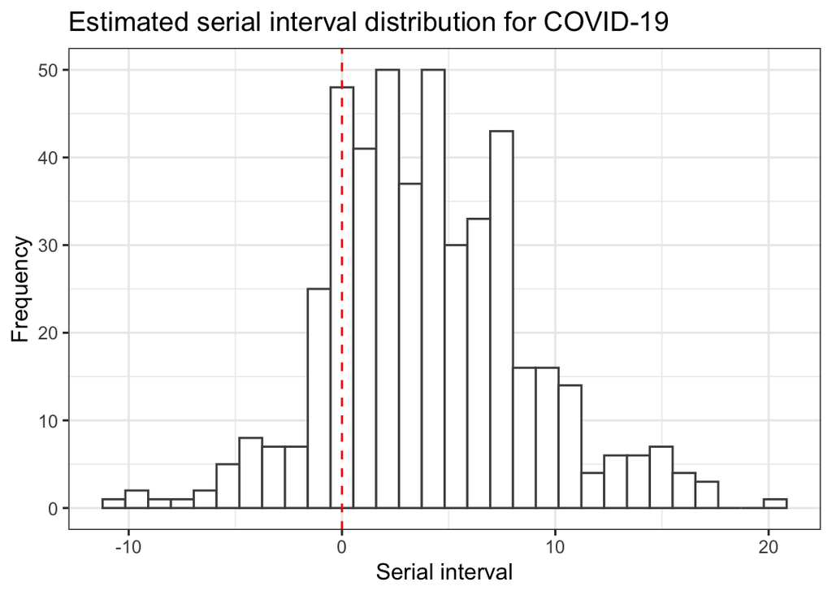

```r
covid19 %>% ggplot(aes(x = serial_int))+
  geom_histogram(bins = 30, color = 'grey30', fill = 'white') +
  geom_vline(xintercept = 0, color = 'red', linetype = 'dashed') +
  theme_bw() + labs(title = 'Estimated serial interval distribution for COVID-19', x = 'Serial interval', y = 'Frequency')
```

The range of serial interval is between -11 and 20. The negative value implies that asymptomatic transmission the COVID-19 occur. Asymptomatic or mildly symptomatic case-patience are indicated by the negative serial intervals found on the left of the red vertical dashed lines.

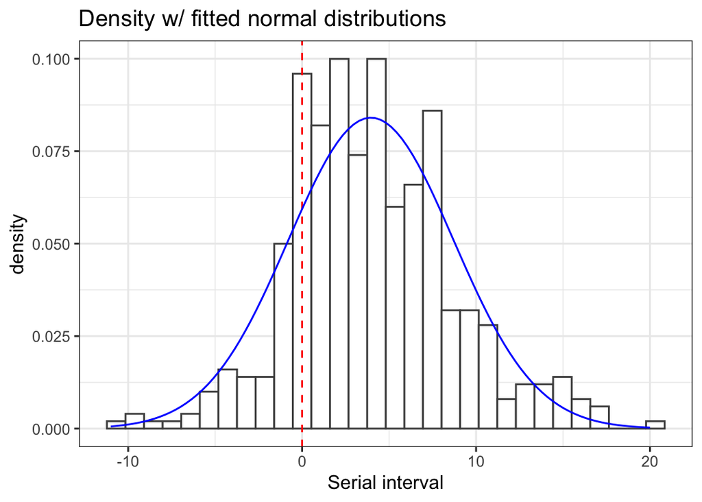

Figure 4.2: Estimated serial interval time with fitted normal distribution for COVID-19 from 468 transmission events.

```r
covid19 %>% ggplot() +
  geom_histogram(aes(x = serial_int, y=..density..), bins = 30, color = 'grey30', fill = 'white') +
  geom_vline(xintercept = 0, color = 'red', linetype = 'dashed') +
  stat_function(fun=dnorm, args = list(mean=mean(covid19$serial_int),
                                       sd=sd(covid19$serial_int)), color='blue') +
  theme_bw() + labs(title = 'Density w/ fitted normal distributions', x = 'Serial interval')
```

```r
# Add column that evaluates local transmission
covid19 <- covid19 %>%
  mutate(transmit_mode = factor(ifelse(index_infection_location == secondary_infection_location, "Local", "Imported")))
```

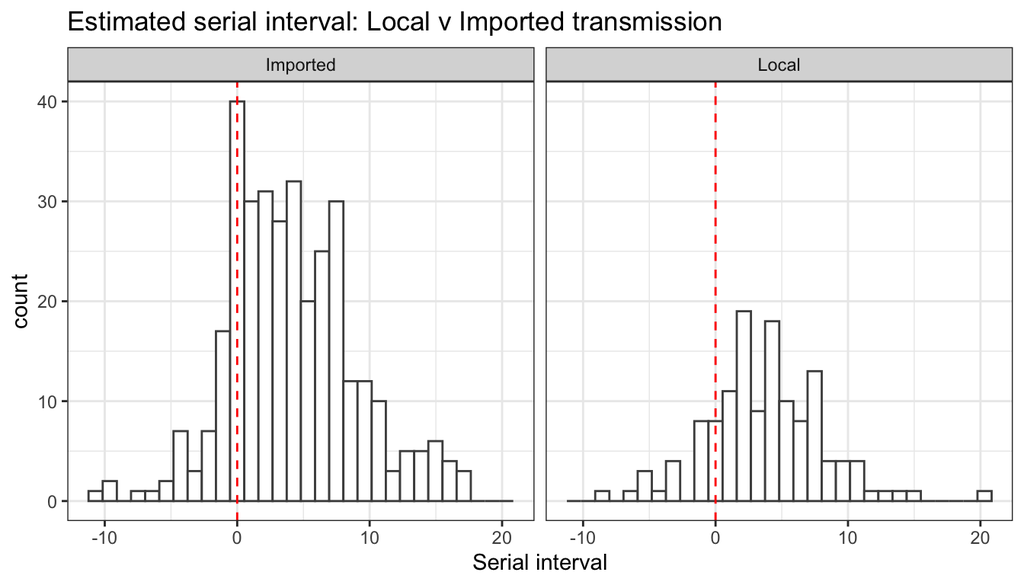

```r
covid19 %>% ggplot(aes(x = serial_int)) +
  geom_histogram(bins = 30, color = 'grey30', fill = 'white') +
  geom_vline(xintercept = 0, color = 'red', linetype = 'dashed') +
  theme_bw() + labs(title = "Estimated serial interval: Local v Imported transmission", x = "Serial interval") + facet_wrap(~transmit_mode)
```

```r
covidLocal <- covid19 %>% filter(transmit_mode == 'Local')
covidImported <- covid19 %>% filter(transmit_mode == "Imported")
covidLocal %>% group_by(serial_int) %>% tally()
```

```
## # A tibble: 23 x 2
##    serial_int     n
##         <dbl> <int>
##  1         -9     1
##  2         -6     1
##  3         -5     3
##  4         -4     1
##  5         -3     4
##  6         -1     8
##  7          0     8
##  8          1    11
##  9          2    19
## 10          3     9
## # … with 13 more rows
```

```r
covid19 %>% group_by(serial_int) %>% tally()
```

```
## # A tibble: 29 x 2
##    serial_int     n
##         <dbl> <int>
##  1        -11     1
##  2        -10     2
##  3         -9     1
##  4         -8     1
##  5         -6     2
##  6         -5     5
##  7         -4     8
##  8         -3     7
##  9         -2     7
## 10         -1    25
## # … with 19 more rows
```

```r
covidLocal %>% group_by(index_id) %>% select(index_id) %>% tally() %>% filter(n > 1)
```

```
## # A tibble: 28 x 2
##    index_id     n
##       <dbl> <int>
##  1       23     2
##  2       60     2
##  3       63     3
##  4       76     3
##  5      154     3
##  6      784     3
##  7     1062     2
##  8     1067     2
##  9     1205     2
## 10     1284     2
## # … with 18 more rows
```

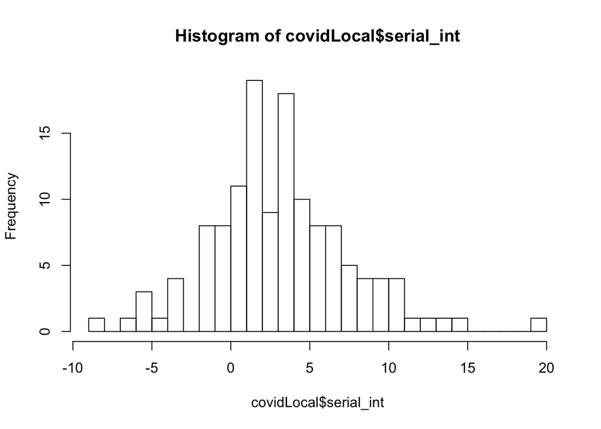

```r
hist(covidLocal$serial_int, breaks = 30)
```

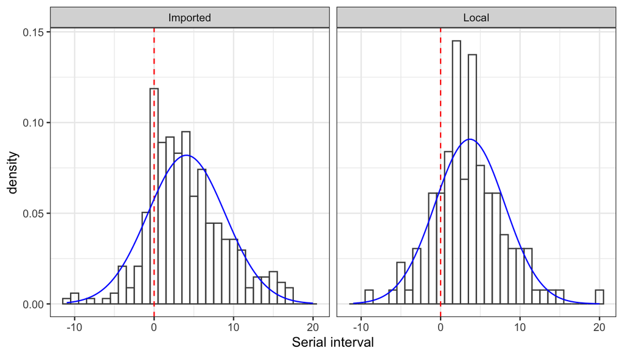

Figure 4.4: Estimated serial interval time for COVID-19 for local and imported transmission between January 21 - February 28, 2020 in mainland China.

```r
gf_histogram(..density.. ~ serial_int | transmit_mode, data = covid19,
             binwidth = 1, color = 'grey30', fill = 'white')%>%
  gf_vline(xintercept=0, color = 'red', linetype = 'dashed') %>%
  gf_fitdistr(dist = 'dnorm', color = 'blue') %>%
  gf_labs(x = 'Serial interval') %>%
  gf_theme(theme = theme_bw())
```

```r
# Create a table of summary of the `\mu`
covSumm <- covid19 %>% group_by(transmit_mode) %>%
  summarise(.n = length(serial_int),
            .mean = mean(serial_int),
            .sd = sd(serial_int),
            .se = qnorm(0.975) * sd(serial_int)/sqrt(length(serial_int)),
            .seplus = mean(serial_int) - (mean(serial_int) + sd(serial_int)/sqrt(length(serial_int))),
            .seminus = mean(serial_int) - (mean(serial_int) - sd(serial_int)/sqrt(length(serial_int))),
            .q683 = quantile(serial_int, 0.683),
            .q954 = quantile(serial_int, 0.954),
            .q997 = quantile(serial_int, 0.997))


covSummAll <- covid19 %>%
  summarise(transmit_mode = "All",
            .n = length(serial_int),
            .mean = mean(serial_int),
            .sd = sd(serial_int),
            .se = qnorm(0.975) * sd(serial_int)/sqrt(length(serial_int)),
            .seplus = mean(serial_int) + (sd(serial_int)/sqrt(length(serial_int)) + mean(serial_int)),
            .seminus = mean(serial_int) - (sd(serial_int)/sqrt(length(serial_int)) - mean(serial_int)),
            .q683 = quantile(serial_int, 0.683),
            .q954 = quantile(serial_int, 0.954),
            .q997 = quantile(serial_int, 0.997))

totalSumm <- rbind(covSumm, covSummAll)

totalSumm %>%
  kable(booktabs = TRUE, caption = 'Table of summary of serial interval by contact type') %>%
  kable_styling(bootstrap_options = c("striped", "hover"), full_width = FALSE)
```

| transmit_mode | .n | .mean | .sd | .se | .seplus | .seminus | .q683 | .q954 | .q997 |
| --- | --- | --- | --- | --- | --- | --- | --- | --- | --- |
| Imported | 337 | 4.065282 | 4.872959 | 0.5202665 | -0.2654470 | 0.2654470 | 6 | 14 | 17.00 |
| Local | 131 | 3.679389 | 4.408501 | 0.7549242 | -0.3851725 | 0.3851725 | 5 | 11 | 18.05 |
| All | 468 | 3.957265 | 4.746044 | 0.4299886 | 8.1339159 | 7.6951439 | 6 | 13 | 17.00 |

```r
#The Contact type column or variable in original data is a chr data type.  To check how many levels of contact type, the data type is set to factor accordingly.  The `fct_count()` can help in validate by listing a tally by group.
covid19 <- covid19 %>% mutate_at(vars(contact_type), factor)
covid19$contact_type %>% fct_count() %>% kable(booktabs = TRUE, caption = 'Table of infection events by contact type') %>%
  kable_styling(bootstrap_options = c("striped", "hover"), full_width = FALSE)
```

Table 4.3: Table of infection events by contact type

| f | n |
| --- | --- |
| Household | 104 |
| No information | 183 |
| Non-household | 180 |
| Non-household’ | 1 |

```r
covid19 <- covid19 %>% mutate(contact_type = fct_relabel(contact_type, str_replace, "Non-household\'", "Non-household"))
covid19Subset <- covid19 %>% mutate(contact_type = fct_relabel(contact_type, str_replace, "Non-household\'", "Non-household"))
covid19$contact_type %>% fct_count() %>% kable(booktabs = TRUE, caption = 'Updated table of infection events by contact type') %>%
  kable_styling(bootstrap_options = c("striped", "hover"), full_width = FALSE)
```

Table 4.4: Updated table of infection events by contact type

| f | n |
| --- | --- |
| Household | 104 |
| No information | 183 |
| Non-household | 181 |

The table shows the correct type of groups in three categories.

### 4.2.2 Boxplots and Violin Plots

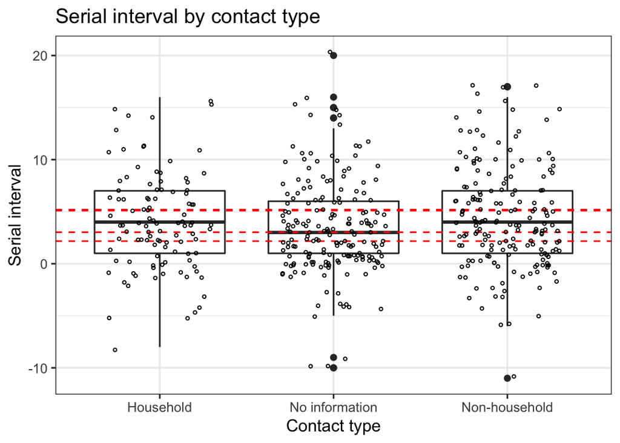

Figure 4.5: Boxplots of the serial interval by contact type.

```r
covid19 %>% ggplot(aes(x = contact_type, y = serial_int)) +
  geom_boxplot() +
  geom_hline(yintercept = c(covSumm$.mean-2*covSumm$.se, covSumm$.mean+2*covSumm$.se),
             color = 'red', linetype = 'dashed') +
  geom_jitter(shape = 1, size = 0.7, width = 0.3) + theme_bw() +
  labs(title = 'Serial interval by contact type', x = 'Contact type', y = 'Serial interval')
```

```r
summContact <- covid19 %>% group_by(contact_type) %>%
  summarise(n = length(serial_int),
            .min = min(serial_int),
            .max = max(serial_int),
            .median = median(serial_int),
            .mean = mean(serial_int),
            .var = var(serial_int),
            .stdev = sd(serial_int),
            .se = sd(serial_int)/sqrt(length(serial_int)))

summContact %>%
  arrange(.mean) %>%
  kable(booktabs = TRUE, caption = 'Table of summary of serial interval by contact type') %>%
  kable_styling(bootstrap_options = c("striped", "hover"), full_width = FALSE)
```

Table 4.5: Table of summary of serial interval by contact type

| contact_type | n | .min | .max | .median | .mean | .var | .stdev | .se |
| --- | --- | --- | --- | --- | --- | --- | --- | --- |
| No information | 183 | -10 | 20 | 3 | 3.404372 | 20.76965 | 4.557373 | 0.3368907 |
| Household | 104 | -8 | 16 | 4 | 4.028846 | 21.95062 | 4.685149 | 0.4594166 |
| Non-household | 181 | -11 | 17 | 4 | 4.475138 | 24.29521 | 4.929017 | 0.3663710 |

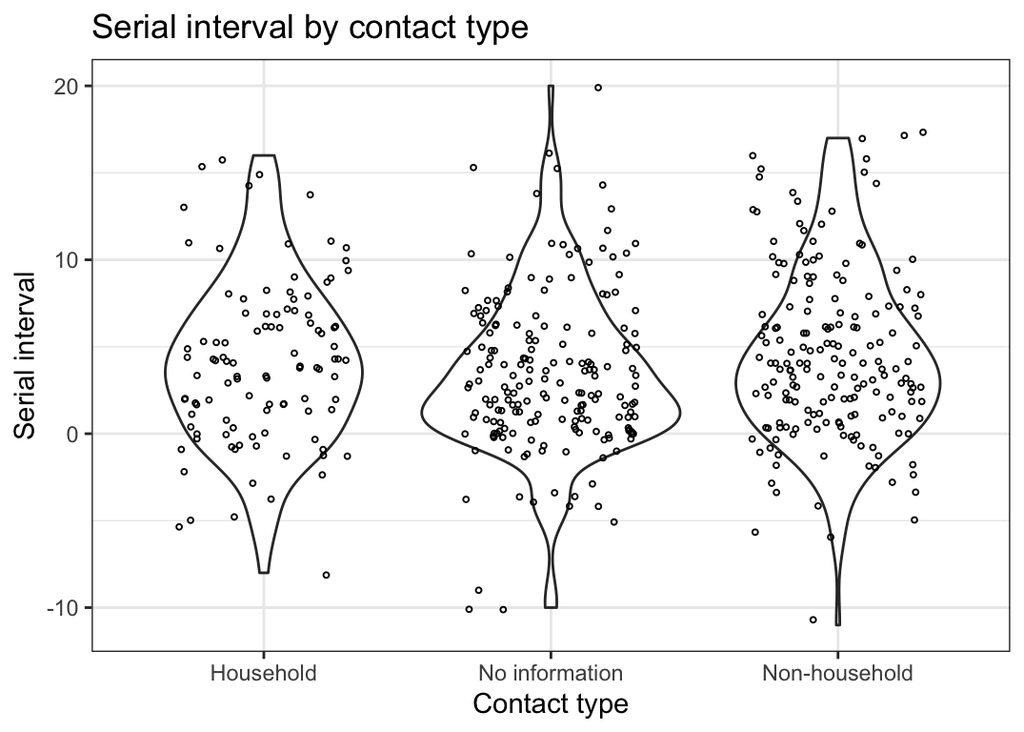

Figure 4.6: Violin Plot of serial interval by contact type.

```r
covid19 %>% ggplot(aes(x = contact_type, y = serial_int)) +
  geom_violin() + geom_jitter(shape = 1, size = 0.7, width = 0.3) + theme_bw() + labs(title = 'Serial interval by contact type', x = 'Contact type', y = 'Serial interval')
```

Violin Plot gives the distribution and probability density of serial interval of the COVID-19 by contact type.